# PG2 - Informe

```r
library("readr")
library("dplyr")
```

```r
library("ggplot2")
library("tidyr")
library("lubridate")
library("vioplot")
library("ggpubr")
library("tidyverse")
library("plan")
DF <- read.csv("heart.csv")
summary(DF)
```

```
##       Age            Sex            ChestPainType        RestingBP
##  Min.   :28.00   Length:918         Length:918         Min.   :  0.0
##  1st Qu.:47.00   Class :character   Class :character   1st Qu.:120.0
##  Median :54.00   Mode  :character   Mode  :character   Median :130.0
##  Mean   :53.51                                         Mean   :132.4
##  3rd Qu.:60.00                                         3rd Qu.:140.0
##  Max.   :77.00                                         Max.   :200.0
##   Cholesterol      FastingBS       RestingECG            MaxHR
##  Min.   :  0.0   Min.   :0.0000   Length:918         Min.   : 60.0
##  1st Qu.:173.2   1st Qu.:0.0000   Class :character   1st Qu.:120.0
##  Median :223.0   Median :0.0000   Mode  :character   Median :138.0
##  Mean   :198.8   Mean   :0.2331                      Mean   :136.8
##  3rd Qu.:267.0   3rd Qu.:0.0000                      3rd Qu.:156.0
##  Max.   :603.0   Max.   :1.0000                      Max.   :202.0
##  ExerciseAngina        Oldpeak          ST_Slope          HeartDisease
##  Length:918         Min.   :-2.6000   Length:918         Min.   :0.0000
##  Class :character   1st Qu.: 0.0000   Class :character   1st Qu.:0.0000
##  Mode  :character   Median : 0.6000   Mode  :character   Median :1.0000
##                     Mean   : 0.8874                      Mean   :0.5534
##                     3rd Qu.: 1.5000                      3rd Qu.:1.0000
##                     Max.   : 6.2000                      Max.   :1.0000
```

Funciones:

```r
cv <- function(x) {
  sd(x, na.rm = TRUE/mean(x, na.rm=TRUE))*100
}
```

**Tema delimitado:** Características que poseen las personas que sufren enfermedades cardíacas

# **Introducción**

## Objetivos

#### Generales

- Analizar las características que poseen las personas que sufren enfermedades cardíacas y determinar una relación entre ellas para poder identificar los factores físicos que influyen en este problema, los comportamientos que las provocan y predecir posibles casos de enfermedades cardíacas.

#### Especificos

- Planificar como se desarrollara el proyecto a lo largo del semestre
- Realizar un análisis de estadística descriptiva de cada variable.
- Establecer correlaciones entre las variables de la base de datos.
- Realizar un análisis estadístico y probabilista en base a la base de datos para obtener conclusiones pertinentes.

## Relevancia e importancia

Las enfermedades cardiovasculares (ECV) son la principal causa de muerte en todo el mundo y se cobran aproximadamente 17.9 millones de vidas cada año, lo que representa el 31% de todas las muertes alrededor del mundo. Es por ello, que las personas con enfermedades cardiovasculares o que tienen un alto riesgo cardiovascular necesitan un diagnóstico y manejo temprano en el que un modelo de aprendizaje automático puede ser de gran ayuda. Es por ello que, en nuestro estudio estadístico, mostramos cuales son los comportamientos que tienden a desarrollar las características más comunes que tienen las personas que sufren del corazón o alguna enfermedad cardíacas, con el fin de que puedan hacer un cambio en su comportamiento diario para prevenir este tipo de enfermedades.

## Planificación

El diagrama de Gantt del proyecto contempla las diferentes entregas parciales y actividades internas del grupo. Se considera como inicio de fecha de ñas actividades a la primera clase del curso y la fecha de fin de actividades el día que se presenta la PG2 - Oral.

```r
library("ggplot2")
library("tidyverse")
library("plan")
df <- data.frame(Actividades=c("Búsqueda de tema", "Relevancia e Importancia","Planteamiento de objetivo e importancia","Informe PG0","Levantamiento de observaciones PG0", "Interpretación de Datos", "Clasificación de variables", "Análisis descriptivo", "Análisis Individual", "Análisis entre variables","Informe PG1","Exposición PG1", "Levantamiendo de observaciones PG1", "Descriptores numéricos","Descriptores gráficos","Análisis probabilístico","Exposición PG2","Informe PG2"),
                 start=c("2022-08-17", "2022-08-24", "2022-08-26", "2022-08-26", "2022-09-02", "2022-09-09", "2022-08-26", "2022-09-08", "2022-09-15","2022-09-18","2022-09-25","2022-09-25","2022-09-30","2022-10-10","2022-10-10","2022-11-05","2022-11-18","2022-11-18"),
                 end=c("2022-08-24", "2022-08-26", "2022-08-29", "2022-09-02", "2022-09-09", "2022-09-12", "2022-09-15", "2022-09-20", "2022-09-25","2022-09-25","2022-09-30","2022-09-30","2022-10-10","2022-11-5","2022-11-18","2022-11-18","2022-11-25","2022-11-25"),
                 Entrega=c("PG0", "PG0", "PG0", "PG0", "PG1", "PG1", "PG1", "PG1", "PG1","PG1","PG1","PG1","PG2","PG2","PG2","PG2","PG2","PG2"))
head(df)
```

|  | Actividades | start | end | Entrega |
| --- | --- | --- | --- | --- |
| 1 | Búsqueda de tema | 2022-08-17 | 2022-08-24 | PG0 |
| 2 | Relevancia e Importancia | 2022-08-24 | 2022-08-26 | PG0 |
| 3 | Planteamiento de objetivo e importancia | 2022-08-26 | 2022-08-29 | PG0 |
| 4 | Informe PG0 | 2022-08-26 | 2022-09-02 | PG0 |
| 5 | Levantamiento de observaciones PG0 | 2022-09-02 | 2022-09-09 | PG1 |
| 6 | Interpretación de Datos | 2022-09-09 | 2022-09-12 | PG1 |

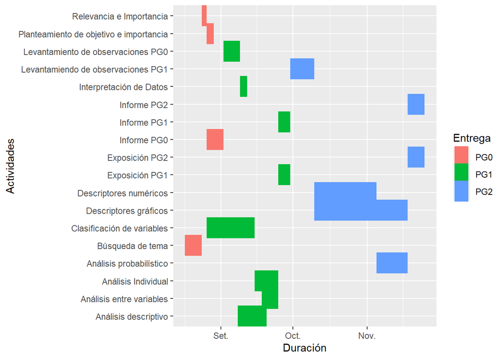

```r
df <- df %>%
  mutate(start = as.Date(start), end = as.Date(end))

df_tidy <- df %>%
  gather(key=date_type, value=Duración, -Actividades, -Entrega)

ggplot() +
  geom_line(data=df_tidy, mapping=aes(x=Actividades, y=Duración, color=Entrega), size=10) +
coord_flip()
```

# **Datos:**

## Proceso de recolección de datos

En este caso, nuestro grupo decidió utilizar una base de datos ya existente. Por lo que el proceso de recolección de datos que se describe será el que realizó por parte de los autores del paper ya mostrado.

El conjunto de datos que nuestro grupo utilizará se creó combinando diferentes conjuntos de datos ya disponibles de forma independiente pero que no se habían combinado antes. En este conjunto de datos se combinan 5 conjuntos de datos cardiacos que combinan 11 caracteres comunes( los cuales serán descritos más abajo). Los 5 conjuntos de datos para la creación son:

- VA Medical Center, Cleveland Clinic EE.UU: 303 observaciones
- Instituto Húngaro de Cardiología, Budapest, Hungria: 294 observaciones
- Hospital Universitario, Basilea, Suiza: 123 observaciones
- VA Medical Center, Fundación de Long Beach EE.UU: 200 observaciones
- Conjunto de Datos de Stalog (corazón): 270 observaciones

Total: 1190 observaciones Duplicado: 272 observaciones Final dataset: 918 observaciones

## Población

Todos los pacientes que se atendieron en las clínicas antes mencionadas y se encuentran registradas en la base de datos interna de su respectiva clinica.

## Muestra

La muestra son todas aquellas personas que sus datos fueron recolectados para la creación de la nueva base de datos conjunta que se encontraron en un rango de edad de 25 - 80 años. Esta muestra se recolectó de manera aleatoria de parte de los autores de la base de datos. No obstante, los datos que ya tenían cada una de las clínicas que se escogieron son datos de personas que tienen preferencia sobre a qué clínica asistir.

## Muestreo

En este caso, nuestro muestreo fue realizado por conglomerado debido a que los creadores de la base de datos conjunta obtuvieron sus observaciones de bases de datos ya establecidas y creadas por las 5 clínicas ya antes mencionadas.

## Variables

#### Categoricas:

- **Sexo**: Sexo del paciente (Masculino/Femenino)
- **Tipo de dolor torácico**: Clasifica a los pacientes de acuerdo al tipo de dolor que tienen en el pecho (TA: angina típica, ATA: angina atípica, NAP: dolor no anginoso, ASY: asintomático)
- **Azúcar en sangre en ayunas**: Cantidad de azúcar que se encuentra en la sangre (1: si BS en ayunas > 120 mg/dl, 0: en caso contrario)
- **Resultados del electrocardiograma en reposo**: Califica a los pacientes de acuerdo a los resultados de un estudio de electrocardiograma(Normal: normal, ST: con anomalías en la onda ST-T (inversión de la onda T y/o elevación o depresión del ST > 0.05 mV), HVI: hipertrofia ventricular izquierda probable o definitiva según los criterios de estrés)
- **Angina inducida por el ejercicio**: Califica a los pacientes, si estos producen Angina por causa de hacer ejercicio (Y: Sí, N: No)
- **ST_Slope**: La pendiente del segmento ST del ejercicio máximo [Arriba: pendiente ascendente, Plana: plana, Abajo: pendiente descendente]
- **Enfermedad cardíaca (1 o 0)**: Clasifica a los paciente que tienen o no una enfermedad cardíaca (1: enfermedad cardíaca, 0: normal)

#### Numericas:

- **Edad**: Contiene la edad de los pacientes en años.
- **Presión arterial en reposo [mm Hg]**: Contiene la presión arterial en reposo de los pacientes.
- **Colesterol [mm/dl]**: Nivel de colesterol de los pacientes.
- **Frecuencia cardíaca máxima alcanzada**: Valor numérico entre 60 y 202.
- **Oldpeak**: ST [Valor numérico medido en depresión]

## Limpieza de base de datos

Debido a que la base de datos con la que vamos a trabajar ya estaba armada, no hay mucha limpieza de datos que hacerle. No obstante, la base de datos está en inglés por lo que nuestro primer paso será pasar el nombre de las variables a español. Asimismo, hemos encontrado un par de datos atípicos en algunas variables numéricas los cuales limpiaremos.

Realizamos un cambio en los nombres para poder trabajar de una manera mas sencilla:

```r
DF %>% rename(Edad = Age, Sexo = Sex, TipoDolorToracico = ChestPainType, PAreposo = RestingBP, Colesterol = Cholesterol, AzucarSangreAyunas = FastingBS, ECGreposo = RestingECG, FCardiacaMax = MaxHR, AnginaInducida = ExerciseAngina, EnfermedadCardiaca = HeartDisease) -> DFF
```

Limpiamos el dato atipo reemplazándolo por un ‘NA’. El cual se identifica por la siguiente tabla:

```r
table(DFF$PAreposo) # Identificamos que hay un solo valor 0, lo cual es imposible porque una persona no puede tener una presión arterial con ese valor.
```

```
##
##   0  80  92  94  95  96  98 100 101 102 104 105 106 108 110 112 113 114 115 116
##   1   1   1   2   6   1   1  15   1   3   3   9   3   7  58  14   1   2  19   2
## 117 118 120 122 123 124 125 126 127 128 129 130 131 132 133 134 135 136 137 138
##   1  10 132  12   2  12  29   7   1  18   1 118   4  17   6  11  20  13   5  17
## 139 140 141 142 143 144 145 146 148 150 152 154 155 156 158 160 164 165 170 172
##   5 107   3  11   2   8  18   4   2  55   7   3   8   2   4  50   1   2  14   2
## 174 178 180 185 190 192 200
##   1   3  12   1   2   1   4
```

```r
DFF$PAreposo[DFF$PAreposo == 0] <- NA # Reemplazamos el valor atípico
```

# **Análisis descriptivo:**

## Análisis Individuales:

#### Categorica Ordinal

- **Tipo de dolor torácico**

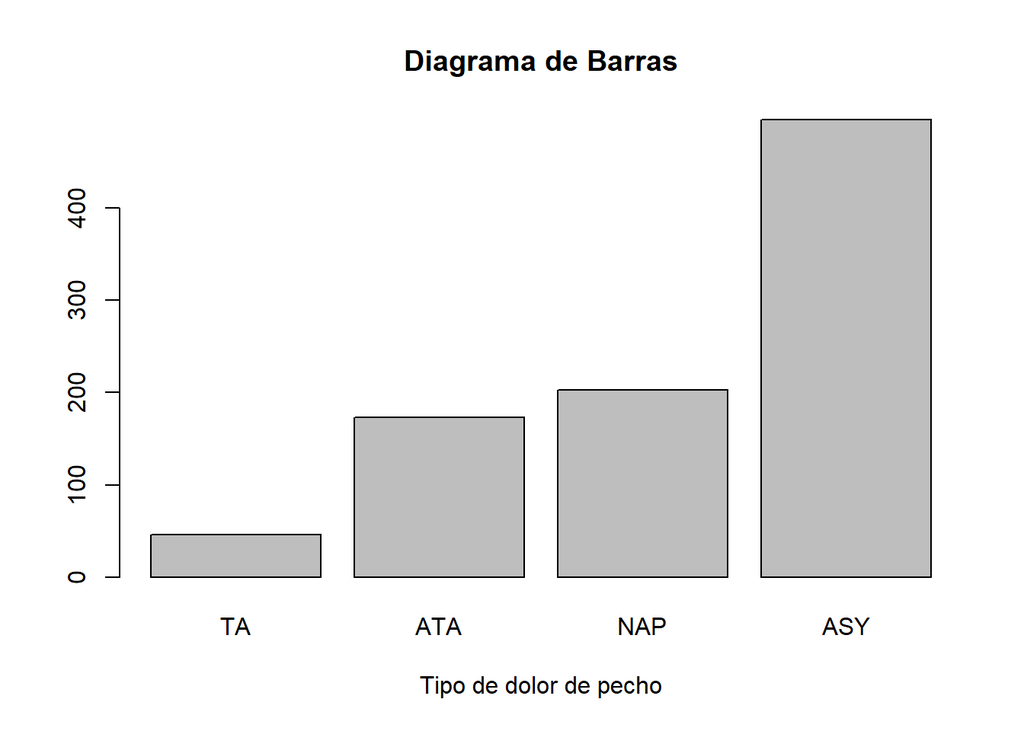

```r
barplot(sort(table(DFF$TipoDolorToracico)), main = "Diagrama de Barras", xlab = "Tipo de dolor de pecho")
```

- **Resultados del electrocardiograma en reposo**

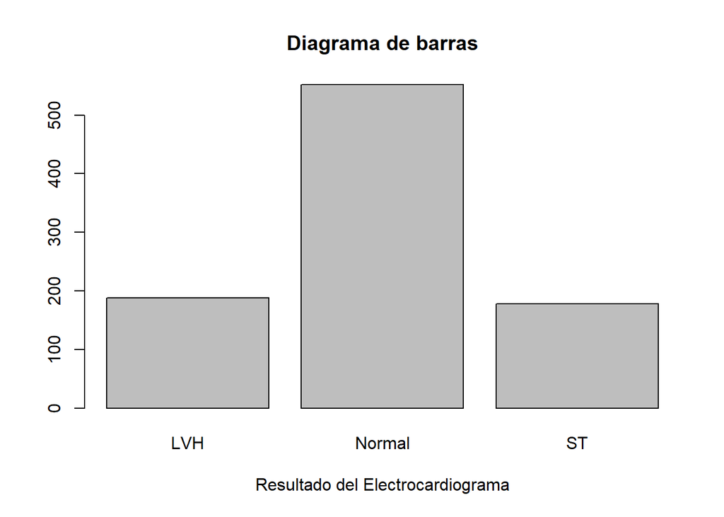

```r
barplot(table(DFF$ECGreposo), main = "Diagrama de barras", xlab = "Resultado del Electrocardiograma")
```

- **ST_Slope**

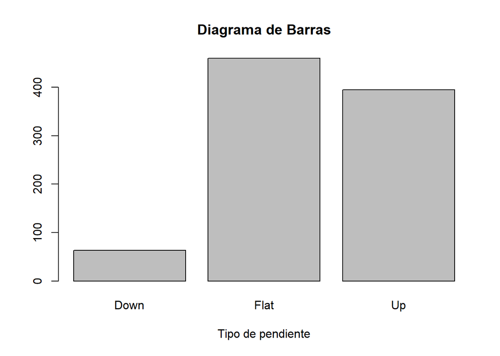

```r
barplot(table(DFF$ST_Slope), main = "Diagrama de Barras", xlab = "Tipo de pendiente")
```

#### Categorica Nominal

- **Azúcar en sangre en ayunas**

```r
DF %>% count(FastingBS) %>% arrange(desc(n))
```

| FastingBS | n |
| --- | --- |
| 0 | 704 |
| 1 | 214 |

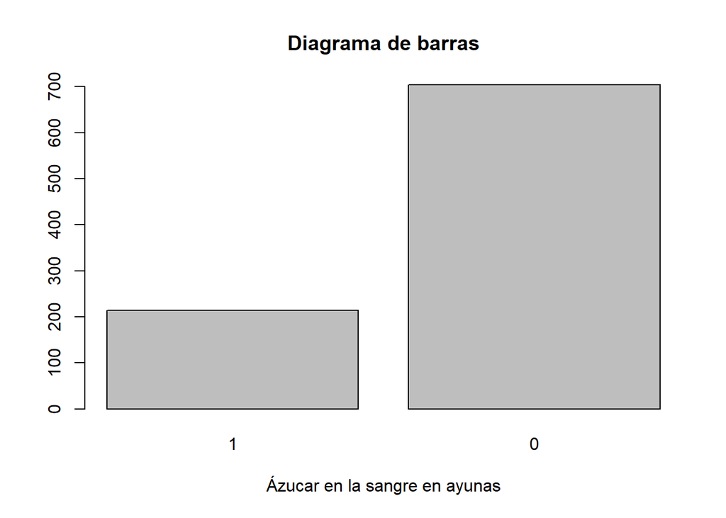

```r
barplot(sort(table(DF$FastingBS)), main = "Diagrama de barras", xlab = "Ázucar en la sangre en ayunas")
```

- **Angina inducida por el ejercicio**

```r
DFF %>% count(AnginaInducida) %>% arrange(desc(n))
```

| AnginaInducida | n |
| --- | --- |
| N | 547 |
| Y | 371 |

- **Enfermedad cardíaca**

  Para hallar la cantidad de observaciones necesarias en base a la variable Enfermedad Cardíaca con $sd(EC) = 0.4974$, un 96% de confianza y considerando un margen de error igual a 0.03 entonces el tamaño mínimo de nuestra muestra debe ser de 843. De la misma forma, si nos basamos en el estudio en base a la variable Frecuencia cardíaca máxima con $sd(FCmax) = 25.46$, un 98% de confianza y un margen de error igual a 1.802 entonces el tamaño mínimo de nuestra muestra debe ser de 843

```r
(sd(DFF$EnfermedadCardiaca) * qnorm(0.96)/0.03)^2
```

```
## [1] 842.577
```

```r
(sd(DFF$FCardiacaMax) * qnorm(0.98)/1.802)^2
```

```
## [1] 842.0024
```

```r
DFF %>% count(EnfermedadCardiaca) %>% arrange(desc(n))
```

| EnfermedadCardiaca | n |
| --- | --- |
| 1 | 508 |
| 0 | 410 |

#### Numerica Discreta

- **Edad**

```r
mean(DFF$Edad)
```

```
## [1] 53.51089
```

```r
median(DFF$Edad)
```

```
## [1] 54
```

```r
sd(DFF$Edad)
```

```
## [1] 9.432617
```

```r
IQR(DFF$Edad, na.rm = TRUE)
```

```
## [1] 13
```

```r
cv(DFF$Edad)
```

```
## [1] 943.2617
```

```r
cuantiles <- quantile(DFF$Edad, type = 2)
cuantiles
```

```
##   0%  25%  50%  75% 100%
##   28   47   54   60   77
```

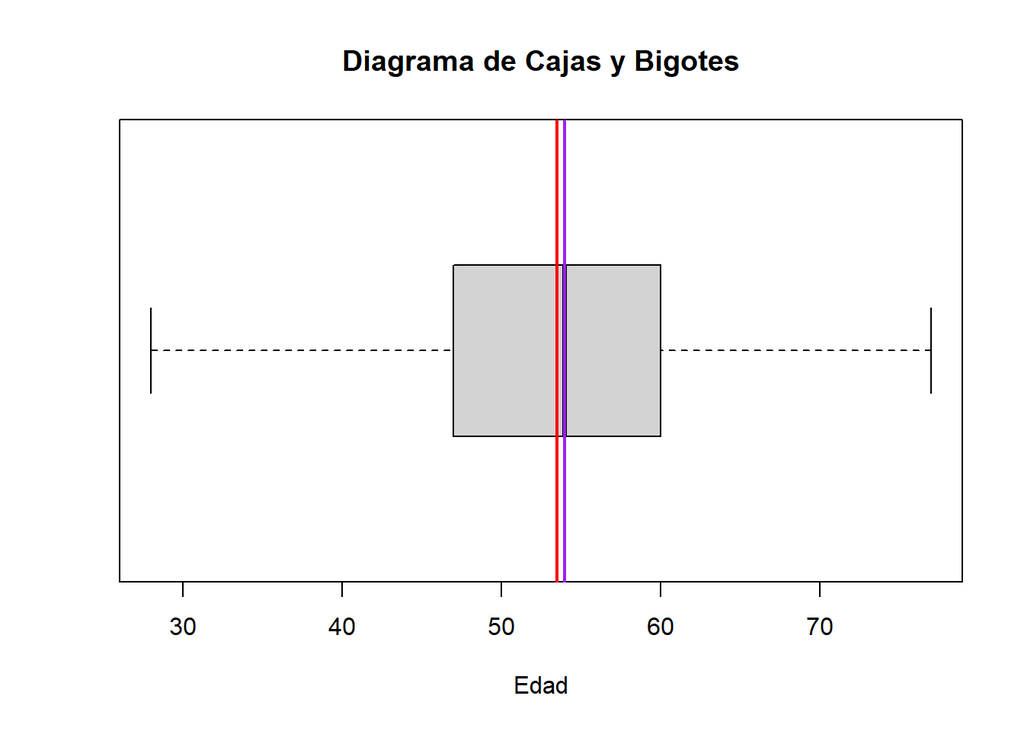

```r
boxplot_edad <- boxplot(DFF$Edad, horizontal = T,  main = "Diagrama de Cajas y Bigotes", xlab = "Edad")
abline(v = mean(DFF$Edad), col = "red", lwd = 2)
abline(v = median(DFF$Edad, na.rm = T), col = "purple", lwd = 2)
```

- **Colesterol**

```r
mean(DFF$Colesterol)
```

```
## [1] 198.7996
```

```r
median(DFF$Colesterol)
```

```
## [1] 223
```

```r
sd(DFF$Colesterol)
```

```
## [1] 109.3841
```

```r
IQR(DFF$Colesterol, na.rm = TRUE)
```

```
## [1] 93.75
```

```r
cv(DFF$Colesterol)
```

```
## [1] 10938.41
```

```r
cuantiles <- quantile(DFF$Colesterol, type = 2)
cuantiles
```

```
##   0%  25%  50%  75% 100%
##    0  173  223  267  603
```

```r
table(DFF$Colesteroll)[table(DFF$Colesterol) == max(table(DFF$Colesterol))]
```

```
## [1] NA
```

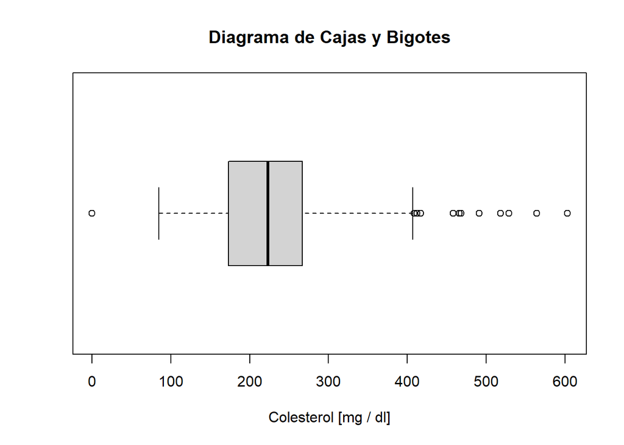

```r
boxplot_edad <- boxplot(DFF$Colesterol, horizontal = T,  main = "Diagrama de Cajas y Bigotes", xlab = "Colesterol [mg / dl]")
```

- **Frecuencia cardíaca máxima alcanzada**

```r
mean(DFF$FCardiacaMax)
```

```
## [1] 136.8094
```

```r
median(DFF$FCardiacaMax)
```

```
## [1] 138
```

```r
sd(DFF$FCardiacaMax)
```

```
## [1] 25.46033
```

```r
IQR(DFF$FCardiacaMax, na.rm = TRUE)
```

```
## [1] 36
```

```r
cv(DFF$FCardiacaMax)
```

```
## [1] 2546.033
```

```r
cuantiles <- quantile(DFF$FCardiacaMax, type = 2)
cuantiles
```

```
##   0%  25%  50%  75% 100%
##   60  120  138  156  202
```

```r
table(DFF$FCardiacaMax)[table(DFF$FCardiacaMax) == max(table(DFF$FCardiacaMax))]
```

```
## 150
##  43
```

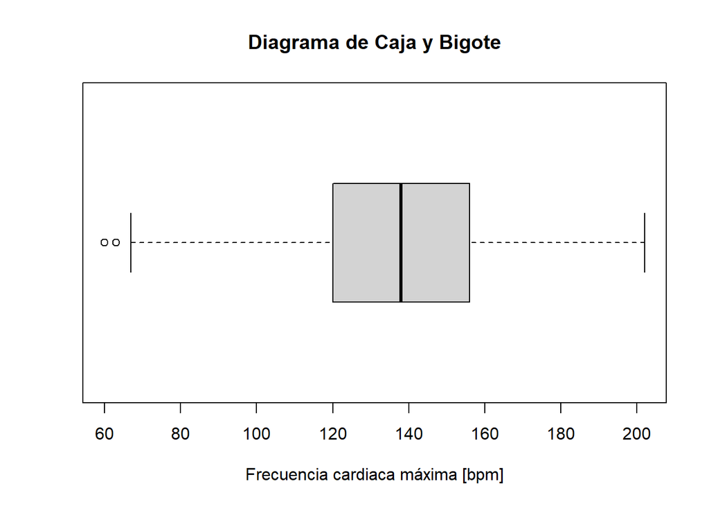

```r
boxplot(DFF$FCardiacaMax, horizontal = T, main = "Diagrama de Caja y Bigote", xlab = "Frecuencia cardiaca máxima [bpm]")
```

- **Presión arterial en reposo**

```r
mean(DFF$PAreposo, na.rm = T)
```

```
## [1] 132.5409
```

```r
median(DFF$PAreposo, na.rm = T)
```

```
## [1] 130
```

```r
sd(DFF$PAreposo, na.rm = T)
```

```
## [1] 17.99975
```

```r
IQR(DFF$PAreposo, na.rm = TRUE)
```

```
## [1] 20
```

```r
cv(DFF$PAreposo)
```

```
## [1] 1799.975
```

```r
cuantiles <- quantile(DFF$PAreposo, type = 2, na.rm = TRUE)
cuantiles
```

```
##   0%  25%  50%  75% 100%
##   80  120  130  140  200
```

```r
table(DFF$PAreposo)[table(DFF$PAreposo) == max(table(DFF$PAreposo))]
```

```
## 120
## 132
```

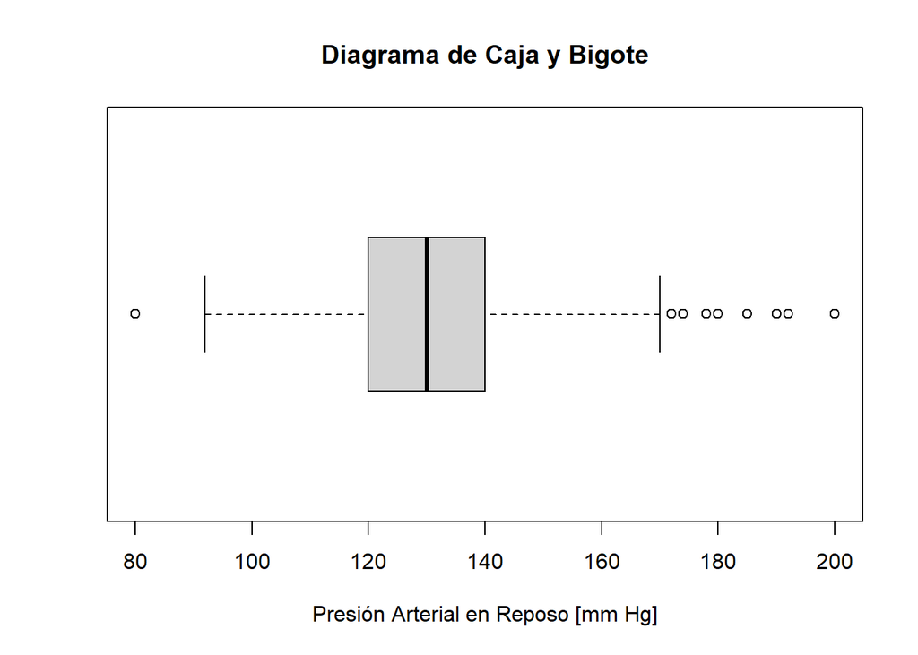

```r
boxplot(DFF$PAreposo, horizontal = T, main = "Diagrama de Caja y Bigote", xlab = "Presión Arterial en Reposo [mm Hg]")
```

#### Numerica Continua

- **Oldpeak**

```r
mean(DFF$Oldpeak)
```

```
## [1] 0.8873638
```

```r
median(DFF$Oldpeak)
```

```
## [1] 0.6
```

```r
sd(DFF$Oldpeak)
```

```
## [1] 1.06657
```

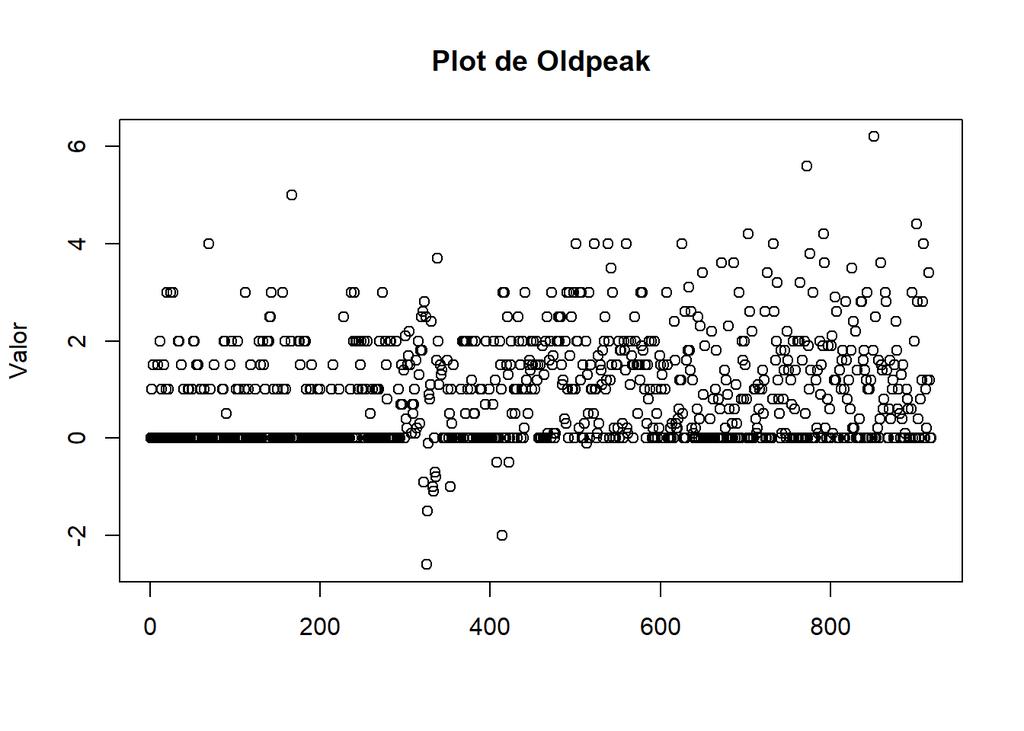

```r
plot(DFF$Oldpeak, main = "Plot de Oldpeak", ylab = "Valor", xlab = " ")
```

## Relaciones entre variables:

- **Primera Relación:** Presión Arterial en reposo en función de la edad de las personas que sufren de una enfermedad cardíaca.

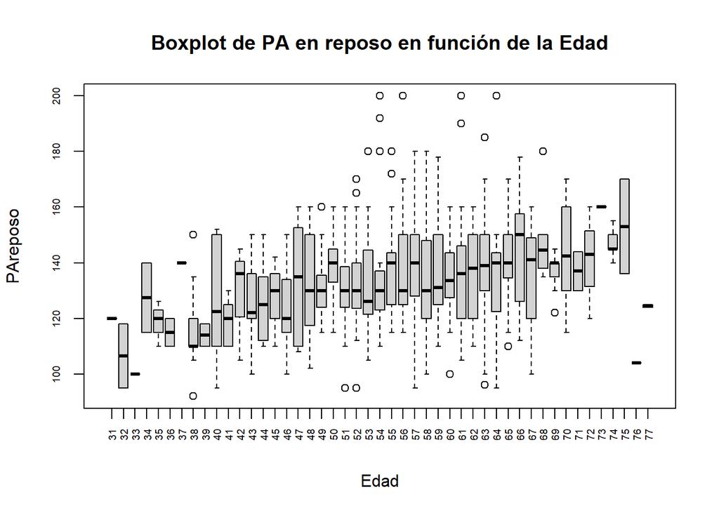

```r
boxplot(DFF$PAreposo[DFF$EnfermedadCardiaca == 1] ~ DFF$Edad[DFF$EnfermedadCardiaca == 1], las = 3, cex.axis = 0.6, xlab = "Edad", ylab = "PAreposo", main = "Boxplot de PA en reposo en función de la Edad")
```

Al analizar la gráfica podemos observar que no existe una relación clara entre estas dos variables. Pero si usamos un boxplot para relacionar variables podemos ver que la existencia de los valores atípicos fuera de los límites del boxplot puede indicar un mal estado de salud del paciente.

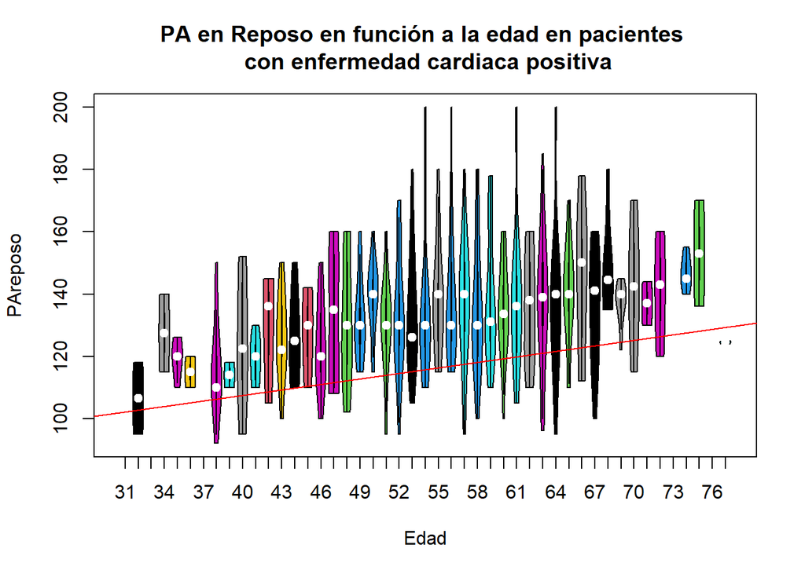

```r
vioplot(DFF$PAreposo[DFF$EnfermedadCardiaca == 1] ~ DFF$Edad[DFF$EnfermedadCardiaca == 1], col = DFF$Edad, xlab = "Edad", ylab = "PAreposo", main = "PA en Reposo en función a la edad en pacientes \n con enfermedad cardiaca positiva")
abline(lm(DFF$PAreposo[DFF$EnfermedadCardiaca == 1] ~ DFF$Edad[DFF$EnfermedadCardiaca == 1]), col = "red")
```

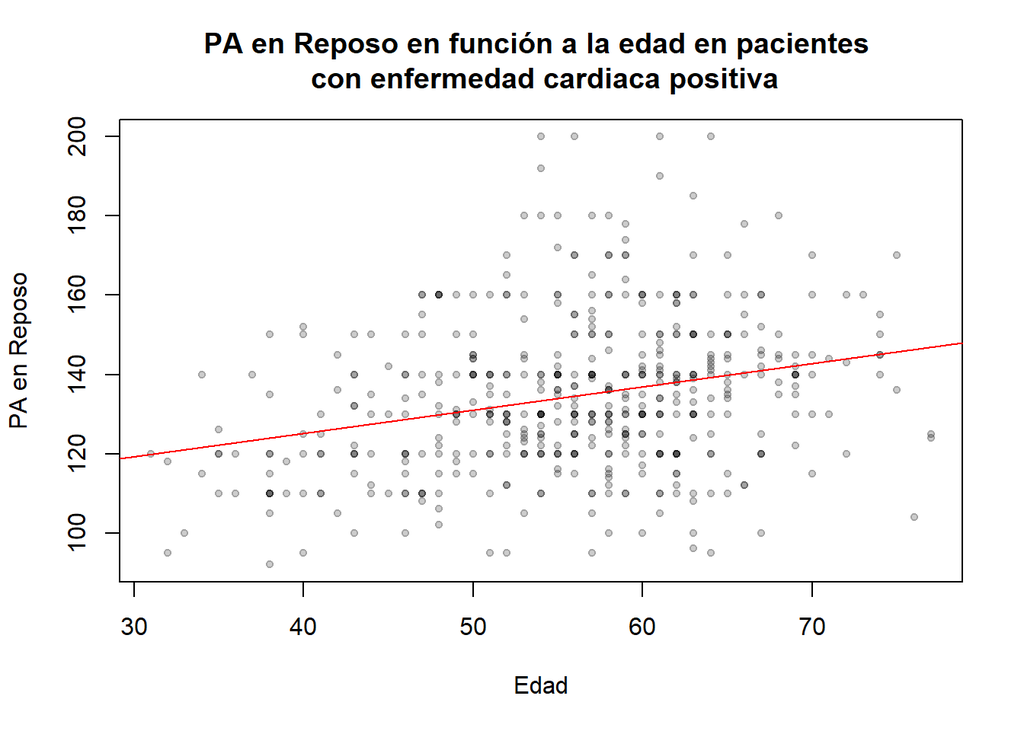

```r
plot(DFF$Edad[DFF$EnfermedadCardiaca == 1], DFF$PAreposo[DFF$EnfermedadCardiaca == 1], pch = 20, col = rgb(0,0,0,0.2), xlab = "Edad", ylab = "PA en Reposo", main = "PA en Reposo en función a la edad en pacientes \n con enfermedad cardiaca positiva")
abline(lm(DFF$PAreposo[DFF$EnfermedadCardiaca == 1] ~ DFF$Edad[DFF$EnfermedadCardiaca == 1]), col = "red")
```

Hallamos el valor de correlación de este caso

```r
a <- cor.test(DFF$PAreposo[DFF$EnfermedadCardiaca == 1], DFF$Edad[DFF$EnfermedadCardiaca == 1], method = "pearson")
a$estimate
```

```
##       cor
## 0.2714081
```

- **Segunda Relación:** Presión Arterial en reposo en función de la edad para personas que no sufren enfermedades cardíacas.

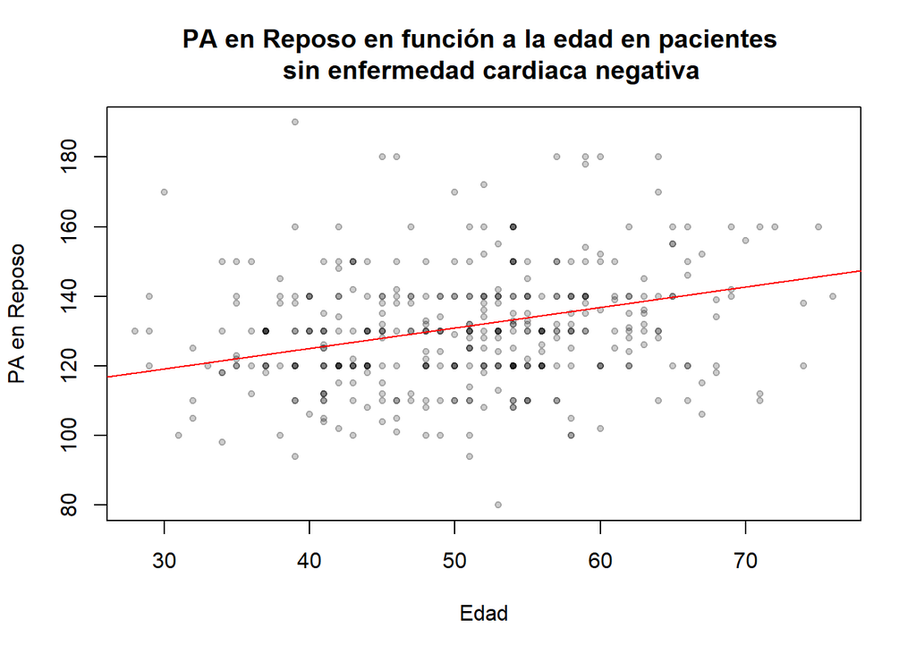

```r
plot(DFF$Edad[DFF$EnfermedadCardiaca == 0], DFF$PAreposo[DFF$EnfermedadCardiaca == 0], pch = 20, col = rgb(0,0,0,0.2), xlab = "Edad", ylab = "PA en Reposo", main = "PA en Reposo en función a la edad en pacientes \n  sin enfermedad cardiaca negativa")
abline(lm(DFF$PAreposo[DFF$EnfermedadCardiaca == 1] ~ DFF$Edad[DFF$EnfermedadCardiaca == 1]), col = "red")
```

```r
(cor.test(DFF$PAreposo[DFF$EnfermedadCardiaca == 0], DFF$Edad[DFF$EnfermedadCardiaca == 0], method = "pearson"))$estimate
```

```
##       cor
## 0.2047653
```

- **Tercera Relación:** Frecuencia cardíaca máxima en función de los pacientes que no sufren de una enfermedad cardíaca

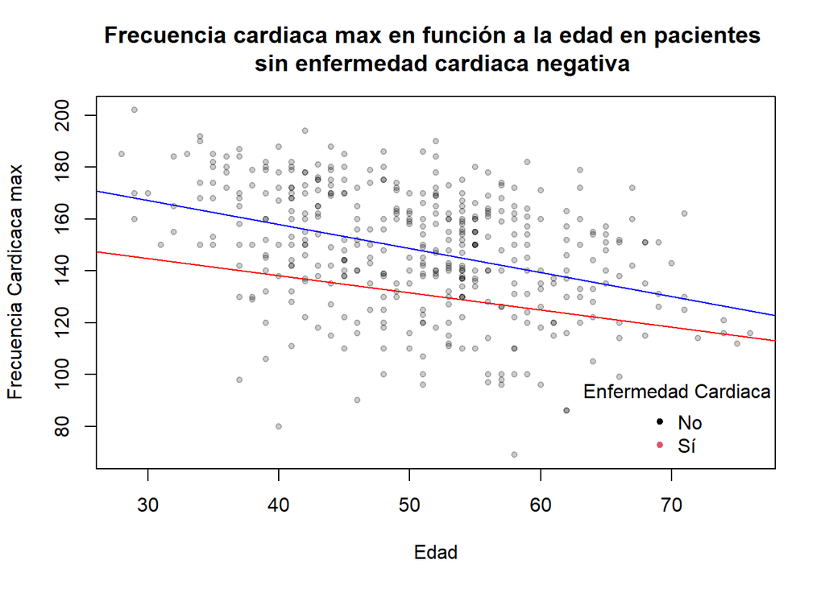

```r
listasino <- as.factor(c("Sí", "No"))
plot(DFF$Edad[DFF$EnfermedadCardiaca == 0], DFF$FCardiacaMax[DFF$EnfermedadCardiaca == 0], pch = 20, col = rgb(0,0,0,0.2), xlab = "Edad", ylab = "Frecuencia Cardicaca max", main = "Frecuencia cardiaca max en función a la edad en pacientes \n  sin enfermedad cardiaca negativa")
abline(lm(DFF$FCardiacaMax[DFF$EnfermedadCardiaca == 0] ~ DFF$Edad[DFF$EnfermedadCardiaca == 0]), col = "blue")

abline(lm(DFF$FCardiacaMax[DFF$EnfermedadCardiaca == 1] ~ DFF$Edad[DFF$EnfermedadCardiaca == 1]), col = "red")
legend("bottomright"
       , legend = levels(listasino)
       , col = 1:3, pch = 20, bty = "n"
       , title = "Enfermedad Cardiaca")
```

```r
(cor.test(DFF$FCardiacaMax[DFF$EnfermedadCardiaca == 0], DFF$Edad[DFF$EnfermedadCardiaca == 0], method = "pearson"))$estimate
```

```
##        cor
## -0.3750085
```

# **Análisis probabilístico:**

## Descripción probabilistica

- **Edad**

  Consideramos que la variable edad es de interés debido a que creemos que existe una relación directamente proporcional con la probabilidad de sufrir una enfermedad cardíaca. Es decir, entre más años de vida tenga una persona, mayor es la probabilidad de que pueda sufrir de una enfermedad cardíaca.

  Esta variable tiene un comportamiento normal como podemos observar en la siguiente gráfica.

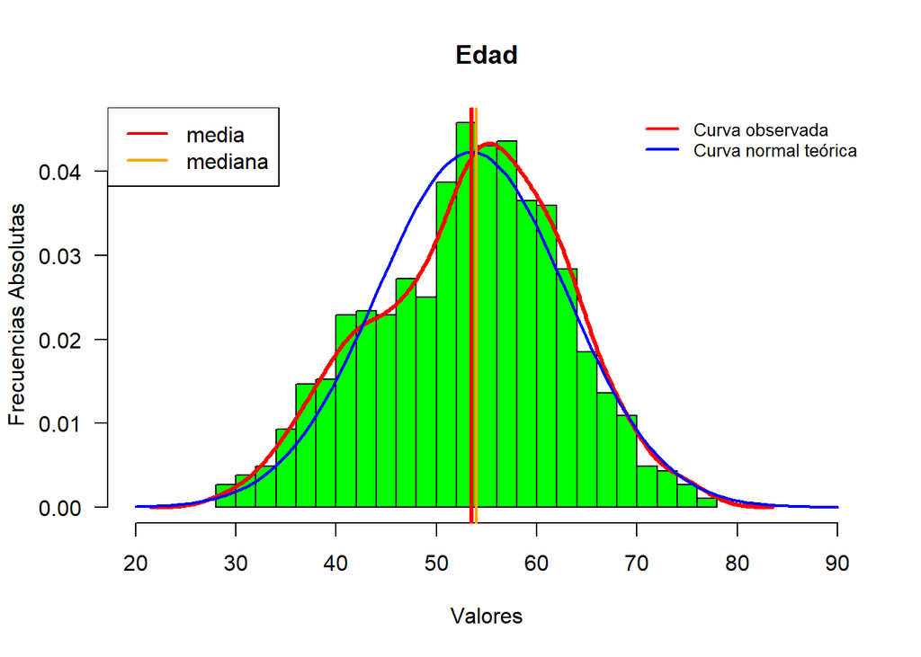

Según nuestro análisis hemos obtenido que existe una probabilidad del 32.4% de que un adulta sufra una enfermedad cardíaca.

```r
per_con_EC <- length(DFF$EnfermedadCardiaca[DFF$EnfermedadCardiaca == 0]) # Personas sin enfermedad cardíaca
per_sin_EC <- length(DFF$EnfermedadCardiaca[DFF$EnfermedadCardiaca == 1]) # Personas con enfermedad cardíaca
prob_per_con_EC <- per_con_EC/nrow(DFF)
prob_per_sin_EC <- per_sin_EC/nrow(DFF)
prob_adul <- (length(DFF$Edad[DFF$Edad < 60]))/nrow(DFF)
prob_adul_con_EC <- prob_adul*prob_per_con_EC
cat('La probabilidad de que un adulto sufra de enfermedad cardiaca es', round(prob_adul_con_EC, 3))
```

```
## La probabilidad de que un adulto sufra de enfermedad cardiaca es 0.324
```

Probabilidad de que un adulto sufra de enfermedad cardíaca

```r
prob_adul <- (length(DFF$Edad[DFF$Edad < 60]))/nrow(DFF)
prob_adul_con_EC <- prob_adul*prob_per_con_EC
cat('La probabilidad de que un adulto sufra de enfermedad cardiaca es', round(prob_adul_con_EC, 3))
```

```
## La probabilidad de que un adulto sufra de enfermedad cardiaca es 0.324
```

Según [La Revista de Cardiología Española](https://www.revespcardiol.org/es-epidemiologia-insuficiencia-cardiaca-articulo-13057268#:~:text=Cerca%20del%201%25%20de%20la,los%20mayores%20de%2070%20a%C3%B1os.) la probabilidad de que una persona adulta mayor a 40 años y menor a 70 sufra de enfermedad cardíaca es de aproximadamente 1%. Al comparar con las probabilidades obtenidas en base a nuestra data podemos observar que los resultados difieren de la realidad, por lo tanto, podemos concluir que nuestra muestra no es lo suficientemente representativa

```r
prob_adul2 <- (length(DFF$Edad[DFF$Edad < 70 & DFF$Edad > 40]))/nrow(DFF)
prob_adul2_con_EC <- prob_adul2*prob_per_con_EC
cat('La probabilidad de que un adulto sufra de enfermedad cardiaca es', round(prob_adul2_con_EC, 3))
```

```
## La probabilidad de que un adulto sufra de enfermedad cardiaca es 0.386
```

```r
length(DFF$Edad[DFF$Edad < 60 & DFF$Edad > 20])
```

```
## [1] 665
```

Probabilidad de que un adulto no sufra de enfermedad cardíaca

```r
prob_adul <- (length(DFF$Edad[DFF$Edad < 60]))/nrow(DFF)
prob_adul_sin_EC <- prob_adul*prob_per_sin_EC
cat('La probabilidad de que un adulto no sufra de enfermedad cardiaca es', round(prob_adul_sin_EC, 3))
```

```
## La probabilidad de que un adulto no sufra de enfermedad cardiaca es 0.401
```

Probabilidad de que un anciano sufra de enfermedad cardíaca

```r
prob_anciano <- (length(DFF$Edad[DFF$Edad >= 60]))/nrow(DFF)
prob_ancia_con_EC <- prob_anciano*prob_per_con_EC
cat('La probabilidad de que un anciano sufra de enfermedad cardiaca es', round(prob_ancia_con_EC, 3))
```

```
## La probabilidad de que un anciano sufra de enfermedad cardiaca es 0.123
```

Probabilidad de que un anciano no sufra de enfermedad cardíaca

```r
prob_anciano <- (length(DFF$Edad[DFF$Edad >= 60]))/nrow(DFF)
prob_ancia_sin_EC <- prob_anciano*prob_per_sin_EC
cat('La probabilidad de que un anciano no sufra de enfermedad cardiaca es', round(prob_ancia_sin_EC,3))
```

```
## La probabilidad de que un anciano no sufra de enfermedad cardiaca es 0.153
```

- **Colesterol**

  La variable colesterol es de importancia en nuestro estudio debido a que sabemos por fuentes externas que es una variable a controlar por parte de los médicos que tratan a personas con enfermedades cardíacas.

  En una primera instancia tratamos de aproximar el comportamiento de esta variable a un comportamiento normal, no obstante como se observa en la gráfica esta no se ajusta del todo.

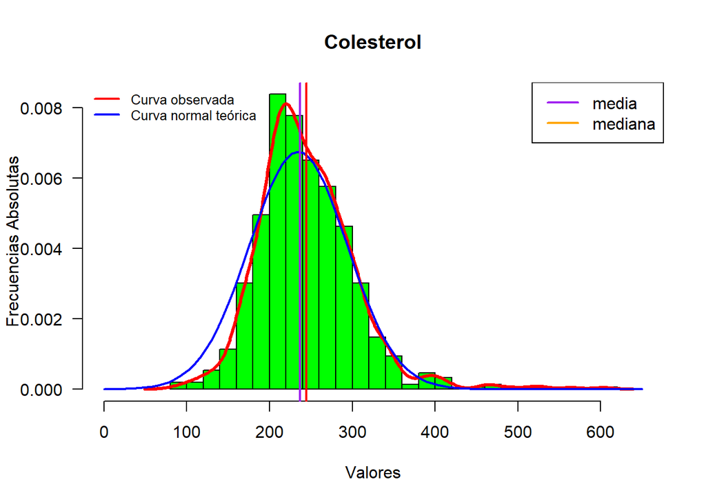

Hayamos las probabilidades para los diferentes casos en los que se podria relacionar la varible colesterol con la enfermedad cárdiaca.

Probabilidad de que una persona sufra de enfermedad cardíaca dado que tiene colesterol normal

```r
prob_Col_normal <- (length(DFF$Colesterol[DFF$Colesterol <= 200]) - length(DFF$Colesterol[DFF$Colesterol == 0]) ) / (nrow(DFF)-length(DFF$Colesterol[DFF$Colesterol == 0]))
prob_Col_nor_con_EC <- prob_Col_normal*prob_per_con_EC
prob_Col_nor_con_EC
```

```
## [1] 0.08980357
```

Probabilidad de que una persona no sufra de enfermedad cardíaca dado que tiene colesterol normal

```r
prob_Col_nor_sin_EC <- prob_Col_normal*prob_per_sin_EC
prob_Col_nor_sin_EC
```

```
## [1] 0.1112688
```

Probabilidad de que una persona sufra de enfermedad cardíaca dado que tiene colesterol anormal

```r
prob_Col_anormal <- (length(DFF$Colesterol[DFF$Colesterol > 200]))/(nrow(DFF) - length(DFF$Colesterol[DFF$Colesterol == 0]))
prob_Col_anor_con_EC <- prob_Col_anormal*prob_per_con_EC
prob_Col_anor_con_EC
```

```
## [1] 0.3568195
```

Probabilidad de que una persona no sufra de enfermedad cardíaca dado que tiene colesterol anormal

```r
prob_Col_anor_sin_EC <- prob_Col_anormal*prob_per_sin_EC
prob_Col_anor_sin_EC
```

```
## [1] 0.4421081
```

- **Frecuencia Cardíaca Máxima**

  En la parte de estadística descriptiva pudimos observar que la variable de frecuencia cardíaca máxima varia dependiendo de muchos factores como la edad, el colestero o si la persona tenia una enfermedad cardíaca o no. Es por ello que consideramos que seria interesante analizar su comportamiento.

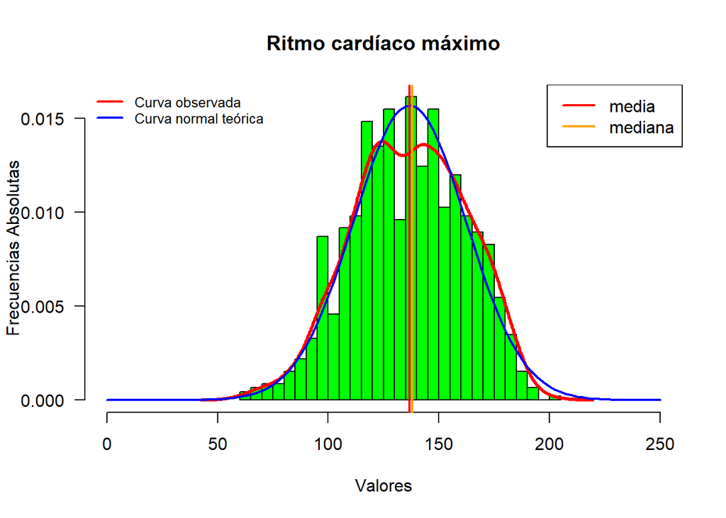

Probabilidad de que una persona sufra de enfermedad cardíaca dado que tiene una frecuencia cardiaca máxima normal

```r
prob_FCmax_nor <- length(DFF$FCardiacaMax[DFF$FCardiacaMax < 100])/nrow(DFF)
prob_FCmax_norm_con_EC <- prob_FCmax_nor*prob_per_con_EC
prob_FCmax_norm_con_EC
```

```
## [1] 0.03454274
```

Probabilidad de que una persona sufra de enfermedad cardíaca dado que tiene una frecuencia cardiaca máxima anormal

```r
prob_FCmax_anor <- length(DFF$FCardiacaMax[DFF$FCardiacaMax >= 100])/nrow(DFF)
prob_FCmax_anorm_con_EC <- prob_FCmax_anor * prob_per_con_EC
prob_FCmax_anorm_con_EC
```

```
## [1] 0.4120803
```

Probabilidad de que una persona no sufra de enfermedad cardíaca dado que tiene una frecuencia cardiaca máxima normal

```r
prob_FCmax_norm_sin_EC <- prob_FCmax_nor * prob_per_sin_EC
prob_FCmax_norm_sin_EC
```

```
## [1] 0.0427993
```

Probabilidad de que una persona no sufra de enfermedad cardíaca dado que tiene una frecuencia cardiaca máxima anormal

```r
prob_FCmax_anorm_sin_EC <- prob_FCmax_anor * prob_per_sin_EC
prob_FCmax_anorm_sin_EC
```

```
## [1] 0.5105776
```

- **Oldpeak**

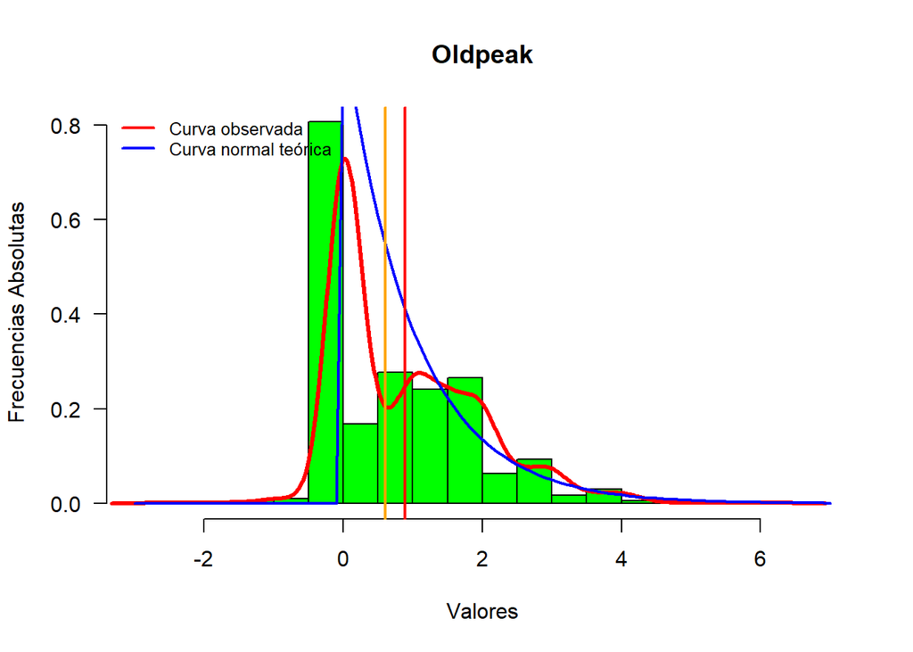

- **Presión Arterial en Reposo:**

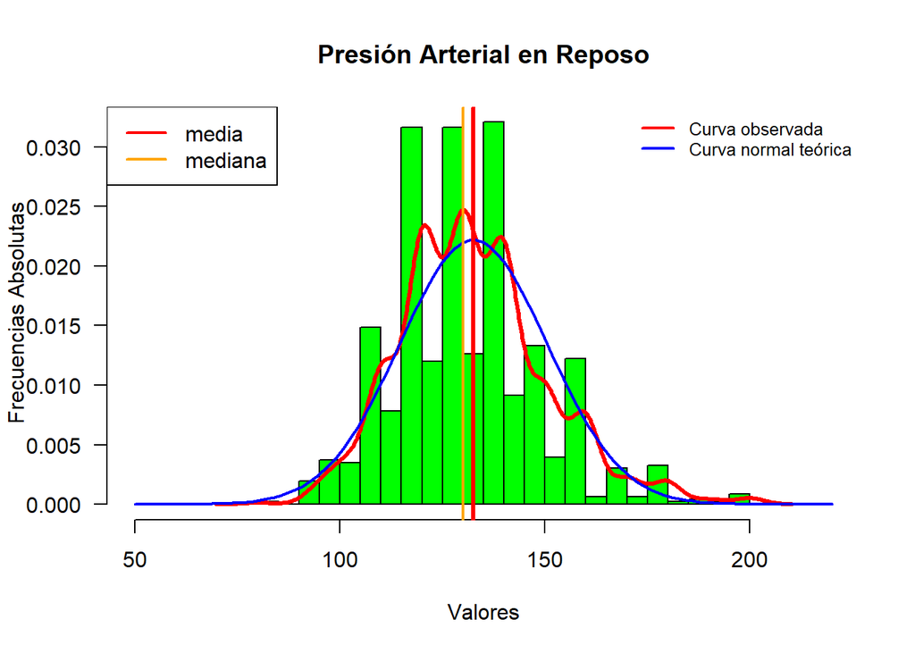

```r
prob_PA_normal <- (length(DFF$PAreposo[DFF$PAreposo < 120 & DFF$PAreposo > 90]))/nrow(DFF)
prob_PA_normal
```

```
## [1] 0.1742919
```

```r
prob_PA_anormal <- (length(DFF$PAreposo[DFF$PAreposo > 120 & DFF$PAreposo < 90]))/nrow(DFF)
prob_PA_anormal
```

```
## [1] 0.001089325
```

- **Sexo**

  Probabilidad de que un varón sufra de enfermedad cardíaca

```r
prob_varon <- (length(DFF$Sexo[DFF$Sexo == "M"]))/nrow(DFF)
prob_var_con_EC <- prob_varon*prob_per_con_EC
cat('La Probabilidad de que un varón sufra de enfermedad cardíaca es', round(prob_var_con_EC, 3))
```

```
## La Probabilidad de que un varón sufra de enfermedad cardíaca es 0.353
```

Probabilidad de que una mujer sufra de enfermedad cardíaca

```r
prob_mujer <- (length(DFF$Sexo[DFF$Sexo == "F"]))/nrow(DFF)
prob_muj_con_EC <- prob_mujer*prob_per_con_EC
cat('La Probabilidad de que una mujer sufra de enfermedad cardíaca es', round(prob_muj_con_EC, 3))
```

```
## La Probabilidad de que una mujer sufra de enfermedad cardíaca es 0.094
```

## Variables Aleatorias

Gráficas del comportamiento de las variables en modelos Binomial y Geométrica

#### Binomial

$$\mathbb{X} - Ber(n,p)$$
$$\mathbb{X} \in [0,918] ~ , ~ n = 918 \to
población, ~ p = 0.447$$

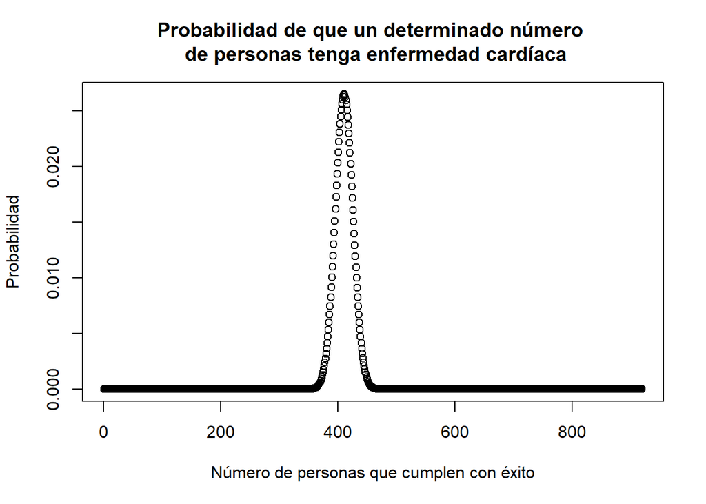

```r
plot(dbinom(c(0:918), 918, prob_per_con_EC), xlab = "Número de personas que cumplen con éxito", ylab = "Probabilidad", main = "Probabilidad de que un determinado número \n de personas tenga enfermedad cardíaca")
```

$$\mathbb{X} - Ber(n,p)$$
$$\mathbb{X} \in [0,918] ~ , ~ n = 918 \to
población, ~ p = 0.324$$

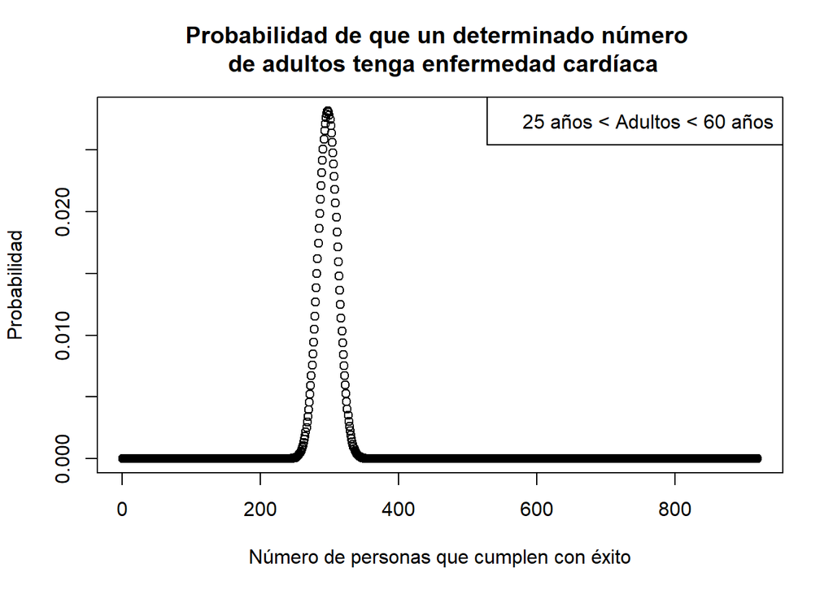

```r
plot(dbinom(c(0:918), 918, prob_adul_con_EC), xlab = "Número de personas que cumplen con éxito", ylab = "Probabilidad", main = "Probabilidad de que un determinado número \n de adultos tenga enfermedad cardíaca")
legend("topright", "25 años < Adultos < 60 años")
```

$$\mathbb{X} \in [0,918] ~ , ~ n = 918 \to
población, ~ p = 0.123$$

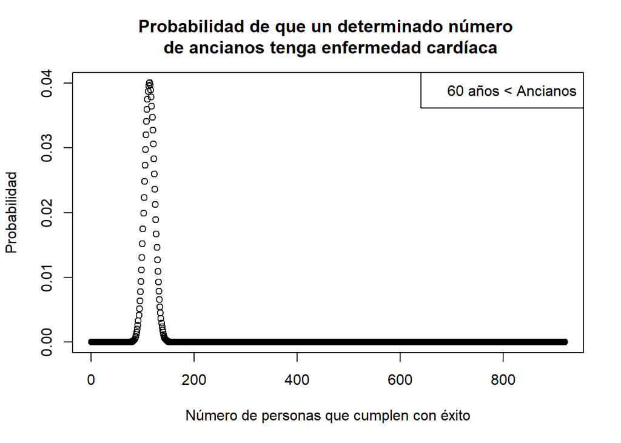

```r
plot(dbinom(c(0:918), 918, prob_ancia_con_EC), xlab = "Número de personas que cumplen con éxito", ylab = "Probabilidad", main = "Probabilidad de que un determinado número \n de ancianos tenga enfermedad cardíaca")
legend("topright", "60 años < Ancianos")
```

$$\mathbb{X} \in [0,918] ~ , ~ n = 918 \to
población, ~ p = 0.357$$

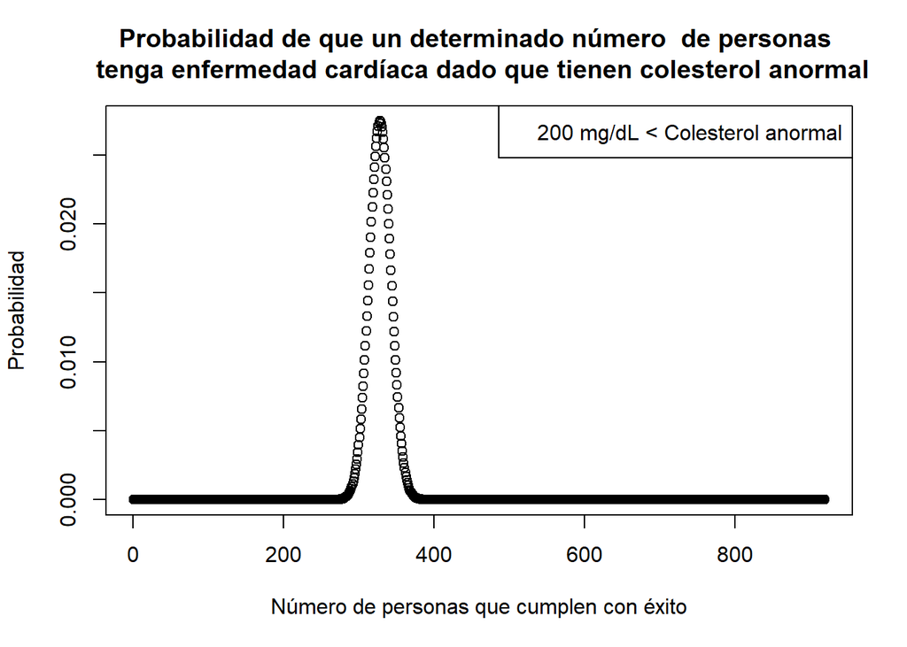

```r
plot(dbinom(c(0:918), 918, prob_Col_anor_con_EC), xlab = "Número de personas que cumplen con éxito", ylab = "Probabilidad", main = "Probabilidad de que un determinado número  de personas \n tenga enfermedad cardíaca dado que tienen colesterol anormal")
legend("topright", "200 mg/dL < Colesterol anormal")
```

$$\mathbb{X} \in [0,918] ~ , ~ n = 918 \to
población, ~ p = 0.09$$

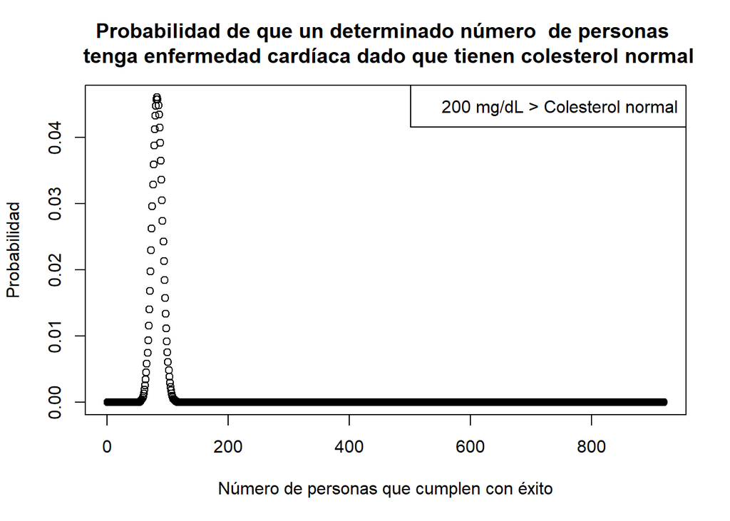

```r
plot(dbinom(c(0:918), 918, prob_Col_nor_con_EC), xlab = "Número de personas que cumplen con éxito", ylab = "Probabilidad", main = "Probabilidad de que un determinado número  de personas \n tenga enfermedad cardíaca dado que tienen colesterol normal")
legend("topright", "200 mg/dL > Colesterol normal")
```

$$\mathbb{X} \in [0,918] ~ , ~ n = 918 \to
población, ~ p = 0.094$$

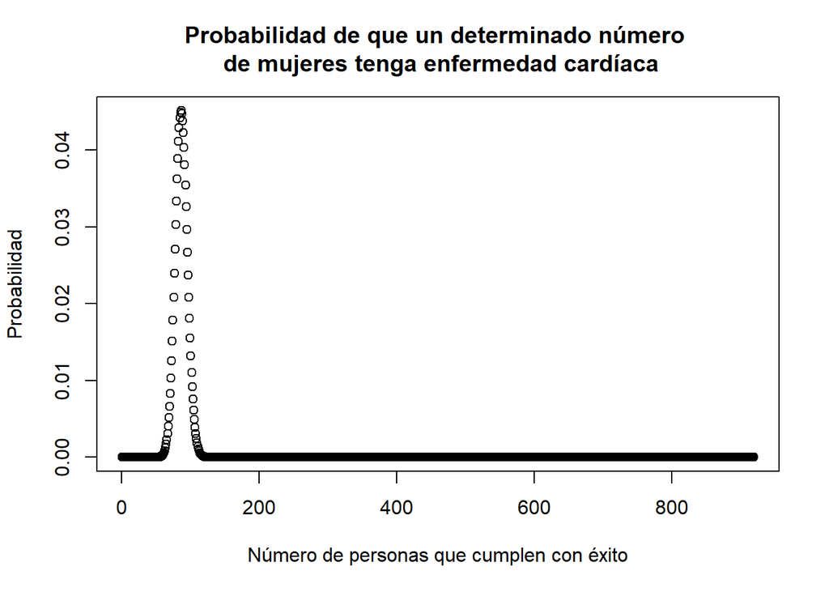

```r
plot(dbinom(c(0:918), 918, prob_muj_con_EC), xlab = "Número de personas que cumplen con éxito", ylab = "Probabilidad", main = "Probabilidad de que un determinado número \n de mujeres tenga enfermedad cardíaca")
```

$$\mathbb{X} \in [0,918] ~ , ~ n = 918 \to
población, ~ p = 0.353$$

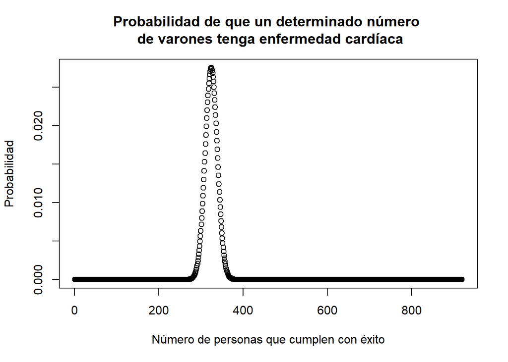

```r
plot(dbinom(c(0:918), 918, prob_var_con_EC), xlab = "Número de personas que cumplen con éxito", ylab = "Probabilidad", main = "Probabilidad de que un determinado número \n de varones tenga enfermedad cardíaca")
```

#### Geométrica

- **Numero de personas a evaluar hasta encontrar una que sufra de enfermedad cardíaca**

  Gráfica de la probabilidad de que tengamos que evaluar a un determinado número de personas hasta encontrar a una que sufra de enfermedad cardíaca.

  $X - Geom(p)$ y $X\in [0, 100]$

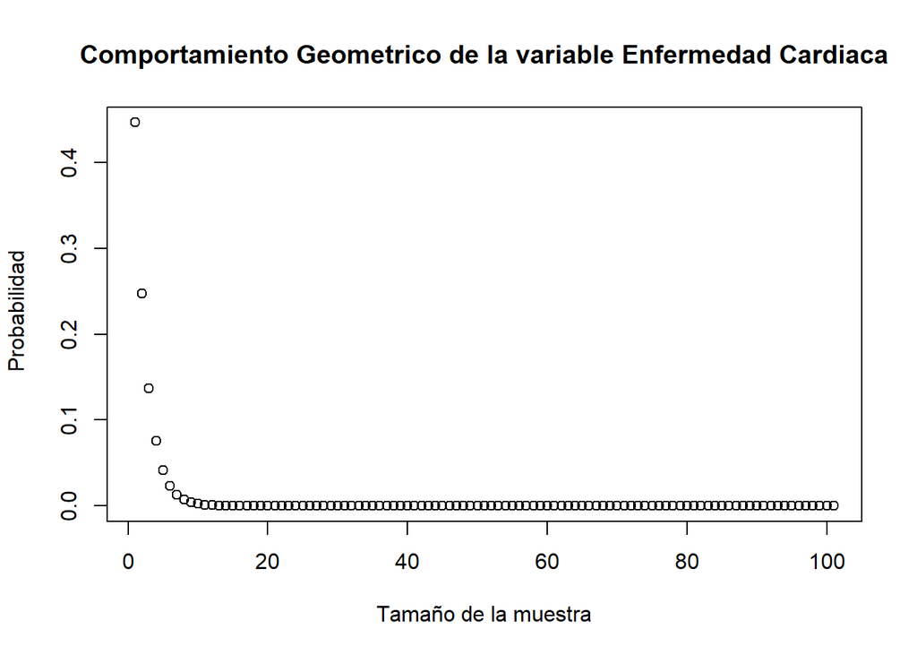

```r
plot(dgeom(0:100, prob_per_con_EC), main = "Comportamiento Geometrico de la variable Enfermedad Cardiaca", ylab = " Probabilidad", xlab = "Tamaño de la muestra")
```